# On a way to Chebyshev polynomials as basis functions for the *tfspline* Python module

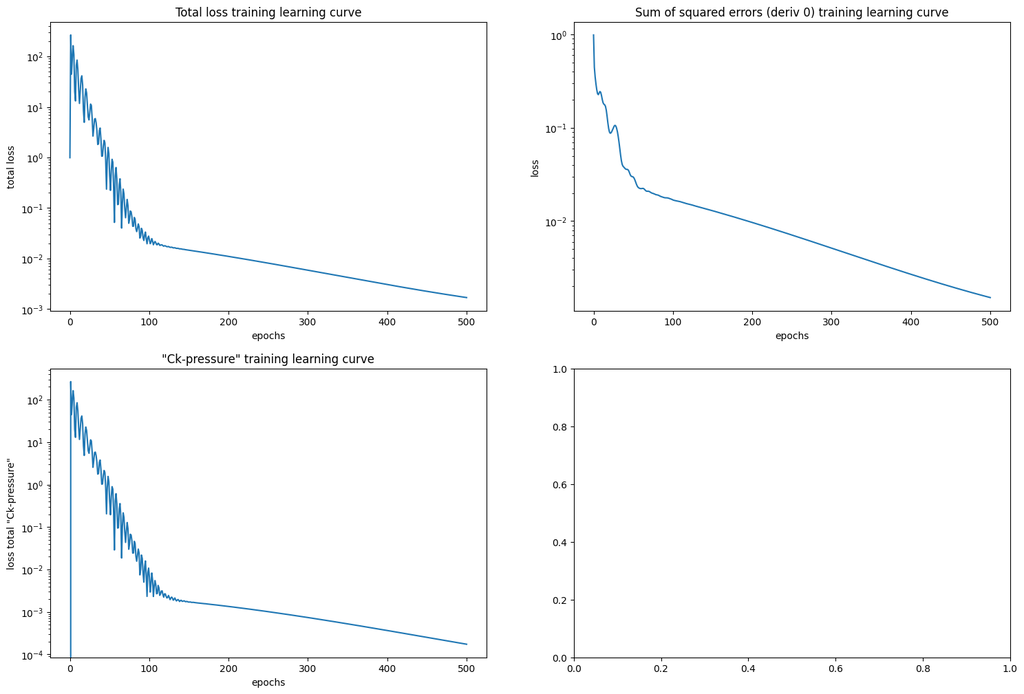

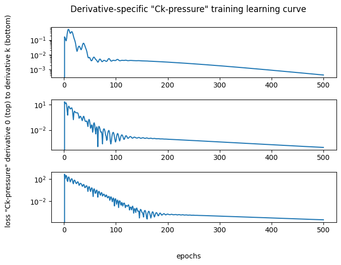

```python
fig, axes = plt.subplots(2, 2, figsize=(18, 12))

# You can now customize each axis as needed
plot.plot_loss(spline_chebyshev, 'total', ax=axes[0][0])
plot.plot_loss(spline_chebyshev, 'approx', ax=axes[0][1])
plot.plot_loss(spline_chebyshev, 'ck-D', ax=axes[1][0])
plot.plot_loss(spline_chebyshev, 'ck-d', ax=axes[1][1])

# Show the plot
plt.show()
```

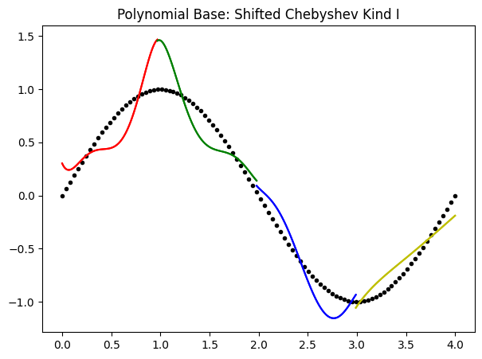

```python
lambd=0.5
spline_shifted_chebyshev = model.Spline(polydegree=degree, polynum=n_segments, ck=ck, basis='shifted_chebyshev', shift_polynomial_centers='boundary')
spline_shifted_chebyshev.continuity = False
opt_sgd = keras.optimizers.SGD(learning_rate=learning_rate, momentum=0.95, nesterov=True)
opt_ams = keras.optimizers.Adam(learning_rate=learning_rate, amsgrad=True)

spline_shifted_chebyshev.fit(data_x, data_y, optimizer=opt_ams, n_epochs=epochs, factor_approximation_quality=lambd,
factor_ck_pressure=1-lambd, initialize_l2fit=False)

plot.plot_spline(spline_shifted_chebyshev, title='Polynomial Base: Shifted Chebyshev Kind I')
```

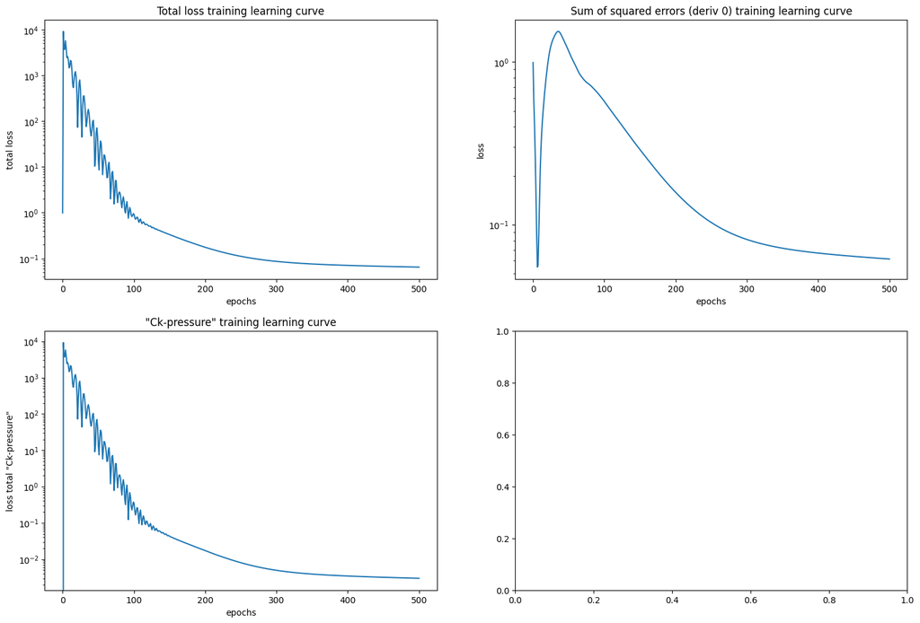

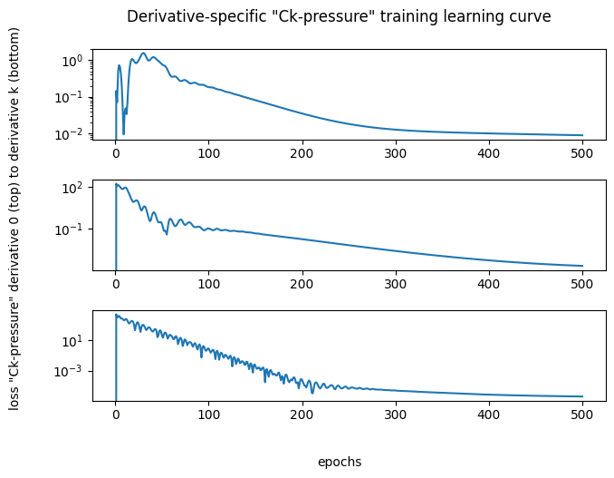

```python
fig, axes = plt.subplots(2, 2, figsize=(18, 12))

# You can now customize each axis as needed
plot.plot_loss(spline_shifted_chebyshev, 'total', ax=axes[0][0])
plot.plot_loss(spline_shifted_chebyshev, 'approx', ax=axes[0][1])
plot.plot_loss(spline_shifted_chebyshev, 'ck-D', ax=axes[1][0])
plot.plot_loss(spline_shifted_chebyshev, 'ck-d', ax=axes[1][1])

# Show the plot
plt.show()
```

### Discussion

With degree 5 polynomials and C^2^ continuity, Power Basis shows the best result in the combined L2 + C^k^-error setting. Interestingly, shifted Chebyshev polynomials produce an unfavourable result although optimization without C^k^ - optimization already produces an almost C^2^ - continuous result.

## More unconventional input

```python
lambd = 1
ck=0
degree=5
```

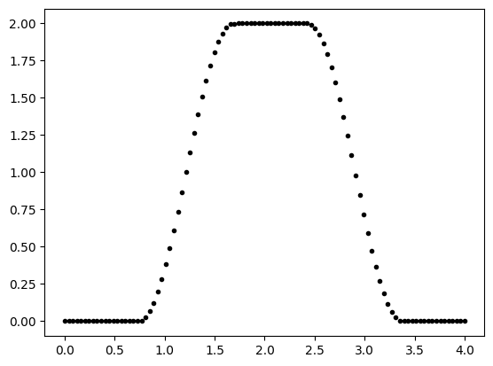

```python
[data_x, data_y] = sampledata.generate_sample_data_cam_table(n=100, noise_factor=0)
data_x = sampledata.rescale_input_data(data_x, n_segments)

# Plot data
plt.plot(data_x, data_y, 'k.')
```

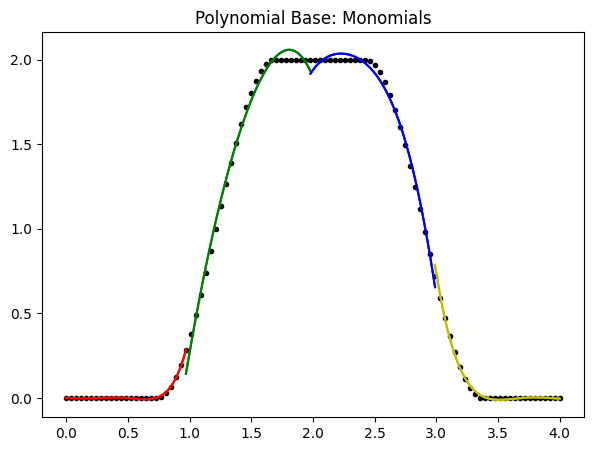

```python
spline_monomial = model.Spline(polydegree=degree, polynum=n_segments, ck=ck)
spline_monomial.continuity = False
opt_sgd = keras.optimizers.SGD(learning_rate=learning_rate, momentum=0.95, nesterov=True)
opt_ams = keras.optimizers.Adam(learning_rate=learning_rate, amsgrad=True)

spline_monomial.fit(data_x, data_y, optimizer=opt_ams, n_epochs=epochs, factor_approximation_quality=lambd,
factor_ck_pressure=1-lambd, initialize_l2fit=False)

plot.plot_spline(spline_monomial, title='Polynomial Base: Monomials')
```

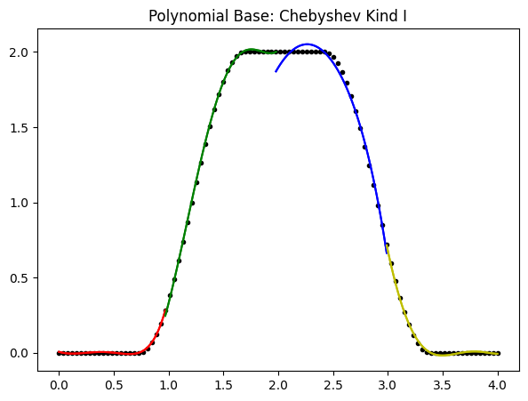

```python
spline_chebyshev = model.Spline(polydegree=degree, polynum=n_segments, ck=ck, basis='chebyshev', shift_polynomial_centers='boundary')
spline_chebyshev.continuity = False
opt_sgd = keras.optimizers.SGD(learning_rate=learning_rate, momentum=0.95, nesterov=True)
opt_ams = keras.optimizers.Adam(learning_rate=learning_rate, amsgrad=True)

spline_chebyshev.fit(data_x, data_y, optimizer=opt_ams, n_epochs=epochs, factor_approximation_quality=lambd,
factor_ck_pressure=1-lambd, initialize_l2fit=False)

plot.plot_spline(spline_chebyshev, title='Polynomial Base: Chebyshev Kind I')
```

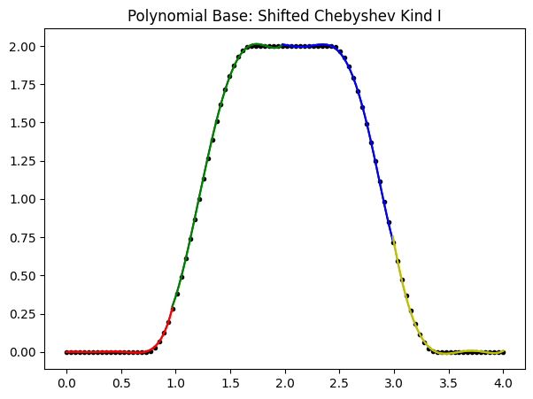

```python
spline_shifted_chebyshev = model.Spline(polydegree=degree, polynum=n_segments, ck=ck, basis='shifted_chebyshev', shift_polynomial_centers='boundary')
spline_shifted_chebyshev.continuity = False
opt_sgd = keras.optimizers.SGD(learning_rate=learning_rate, momentum=0.95, nesterov=True)
opt_ams = keras.optimizers.Adam(learning_rate=learning_rate, amsgrad=True)

spline_shifted_chebyshev.fit(data_x, data_y, optimizer=opt_ams, n_epochs=epochs, factor_approximation_quality=lambd,
factor_ck_pressure=1-lambd, initialize_l2fit=False)

plot.plot_spline(spline_shifted_chebyshev, title='Polynomial Base: Shifted Chebyshev Kind I')
```

### Discussion

By far the best result is achieved using shifted Chebyshev polynomials as a basis.

## Test Spline from coeffs function

This functionality is required to create splines from coeffs returned by model.parallel() experiments, as the tf.Spline class is not picklable and cannot be returned by parallel tasks under Windows. See https://docs.python.org/2/library/multiprocessing.html#windows .

```python
lambd=1
degree=3
ck=1
n_segments=3
epochs=500
learning_rate = 1

[data_x, data_y] = sampledata.generate_sample_data_sin(n=100, f=1, noise_factor=0)
data_x = sampledata.rescale_input_data(data_x, n_segments)
```

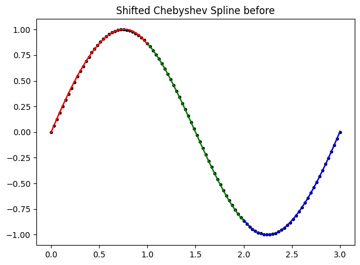

```python
spline_shifted_chebyshev = model.Spline(polydegree=degree, polynum=n_segments, ck=ck, basis='shifted_chebyshev', shift_polynomial_centers='boundary')
spline_shifted_chebyshev.continuity = False
opt_sgd = keras.optimizers.SGD(learning_rate=learning_rate, momentum=0.95, nesterov=True)
opt_ams = keras.optimizers.Adam(learning_rate=learning_rate, amsgrad=True)

spline_shifted_chebyshev.fit(data_x, data_y, optimizer=opt_ams, n_epochs=epochs, factor_approximation_quality=lambd,
factor_ck_pressure=1-lambd, initialize_l2fit=False)

plot.plot_spline(spline_shifted_chebyshev, title='Shifted Chebyshev Spline before')
```

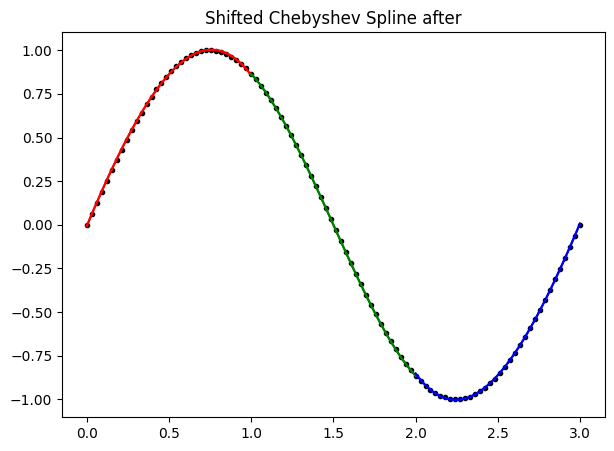

```python
new_spline = model.get_spline_from_coeffs(coeffs=spline_shifted_chebyshev.coeffs, data_x=data_x, data_y=data_y, ck=ck, basis='shifted_chebyshev', continuity=False)
plot.plot_spline(new_spline, title='Shifted Chebyshev Spline after')
```

It works!

# Things that do not work with new basis

## Strictly establishing continuity via algorithm

Old approach doesn't directly apply to new setting - We use Power Basis coefficients in the algorithm which don't go along with Chebyshev series coefficients.

## L2-fit initialization

Dito.